# Speeding on Interstate 5 and Blackjack

### Getting started

Navigate to Moodle folder **Data, Quarto and R files - Sample solutions and previous problem sets**. Locate the Quarto document named `starter_speeding_bj.qmd` and open it in RStudio (or your preferred IDE). Before proceeding, check if there are any packages you need to install that are required for the code. Then try to render the document, to make sure it compiles without errors before you start editing.

### Packages

We’ll use the **tidyverse** package(s) for data wrangling, visualization and reading in data.

You can load the package by running the following code:

```r
library(tidyverse)
```

> **Note:** Whenever you need to compute a probability, you have to provide, in addition to your numerical result, either the appropriate R code or a mathematical formula explaining how the probability was calculated.

*Remark*. You can use [TeX commands](https://www.overleaf.com/learn/latex/Mathematical_expressions) to write formulas in your solution, **if you want to**. Just be aware to use `$` to start an inline formula (instead of `\(`) and `$$` to create a centered formula (instead of `\[`).

As an example, consider the case that the probability of the event $A$ is given as the product of the two probabilities $p,q\in [0,1]$:
$$P(A) = p \cdot q.$$

In this homework, we want to introduce the idea of [Monte Carlo simulations](https://en.wikipedia.org/wiki/Monte_Carlo_method). We start with an example explaining the concept. After the example, you will find several exercises. In some of them, you can apply the idea of the Monte Carlo simulation.

**Example 1** If there are two red beads and three blue beads in an urn, and you pick one randomly, what is the probability of choosing a red bead?

```r
red <- 2
blue <- 3
beads <- red + blue

red/beads
```

```
[1] 0.4
```

This problem is easy to solve, and we can compute the probability analytically. But let’s assume for a moment that this is not the case.

We are considering using a method called Monte Carlo simulation. The concept is to randomly sample from the probability model we are studying (for instance, picking a bead from an urn) and then repeat the experiment a sufficient number of times to make the results effectively equivalent to performing the experiment an infinite number of times (remember our frequentist interpretation of probability in Chapter 7.1.3).

Random number generators allow us to simulate the process of random selection. An example is the `sample()` function in R.

```r
urn <- rep(c("red", "blue"), times = c(2,3))
urn
```

```
[1] "red"  "red"  "blue" "blue" "blue"
```

Now we use `sample()` to pick a bead at random:

```r
sample(urn, 1)
```

```
[1] "blue"
```

To perform our first Monte Carlo simulation, we use the replicate() function, which permits us to repeat the same task any number of times. Here, we repeat the random event B = 10000 times.

```r
B <- 10000
events <- replicate(B, sample(urn, 1))
```

The proportion of red beads in `events` is then the Monte Carlo approximation of the probability $\frac{2}{5}=0.4$.

```r
events |>
  table() |>
  prop.table()
```

```
events
  blue    red
0.5909 0.4091
```

*Remark*. The `replicate()` function allows us to repeatedly evaluate an input function (in the example, it was `sample()`) in a nice and easy way. The first argument to `replicate()` defines how often the second argument (the function) should be evaluated. Hence, whenever you want to use `replicate()`, you need to provide a function for evaluation. Sometimes, the function you have in mind is not one which is already implemented. In these cases you have to write your own function using `function()`. Consider this simple example to get the idea of how to write a function:

```r
affine_func <- function(x = 1, slope = 1, intercept = 0){
  y <- intercept + slope * x
  return(y)
}

affine_func(2, 2, 0)
```

```
[1] 4
```

```r
affine_func() # default values for three arguments
```

```
[1] 1
```

## Solutions

### Speeding on Interstate 5

A study investigated the distribution of passenger vehicle speeds traveling on the [Interstate 5 Freeway](https://en.wikipedia.org/wiki/Interstate_5) (I-5) in California. They discovered that the **distribution is nearly normal** with a **mean of 72.6 miles/hour** and a **standard deviation of 4.78 miles/hour**.

*Solution 1*.

1. The speed of passenger vehicles follows a normal distribution, with a mean of 72.6 and a standard deviation of 4.78. Therefore, the probability is given by:

   ```r
   pnorm(80, mean = 72.6, sd = 4.78)
   ```

   ```
   [1] 0.939203
   ```

2. The fastest 5% corresponds to the the upper 5% tail, i.e. speeds above the 95th quantile (~80.46 mph).

   ```r
   qnorm(0.95, mean = 72.6, sd = 4.78)
   ```

   ```
   [1] 80.4624
   ```

3. We want to calculate the probability of traveling at a speed greater than 70 miles per hour.

```r
P_speeding <- 1 - pnorm(70, mean = 72.6, sd = 4.78)
P_speeding
```

```
[1] 0.7067562
```

*Solution 2*. The officer is watching five Bernoulli trials (speeding yes/no) and counts the number of successes (car is speeding).

The probability for the event that all five cars passing by are not speeding is then given by

$$(1 - \mathrm{P\_speeding})^5 = (1 - 0.7067562)^5 = 0.002168423$$

*Solution 3*.

```r
first_speeding <- function(){
  count <- NULL              # initialize the counting of cars
  while(sum(count) == 0){    # loop over the next command until the sum is not
                             # equal to 0 anymore
    count <-
      c(count,
        ifelse(
          rnorm(1, mean = 72.6, sd = 4.78) > 80, # simulate speed of car and check if it is speeding
          1,                 # new value in the case of speeding
          0))                # new value if the car is not speeding
  }
  return(length(count)) # number of observed cars
}
```

After setting the seed, we can use `replicate()` to simulate values from the function `first_speeding()` multiple times.

```r
set.seed(1)
B <- 10000
num_cars_first_speeding <- replicate(B, first_speeding())
mean(num_cars_first_speeding)
```

```
[1] 16.3578
```

*Solution 4*.

```r
speed_data <- read_csv("data/speed_data.csv")
```

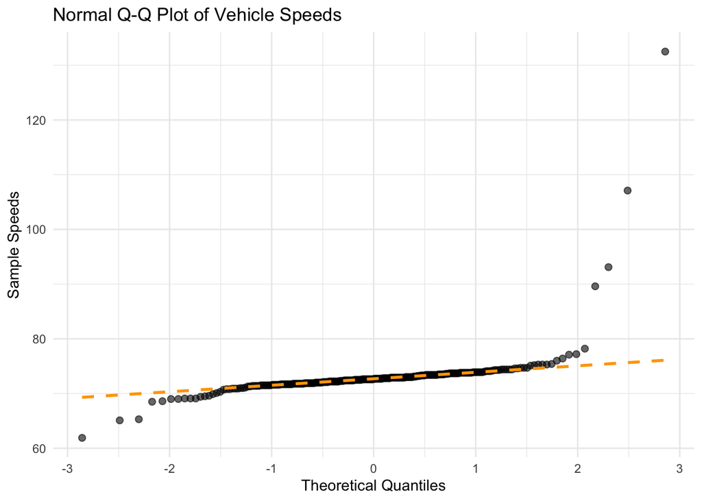

```r
ggplot(speed_data, aes(sample = speed)) +
  stat_qq(color = "black", size = 2, alpha = 0.6) +
  stat_qq_line(color = "orange", linetype = "dashed", size = 1) +
  labs(
    title = "Normal Q-Q Plot of Vehicle Speeds",
    x = "Theoretical Quantiles",
    y = "Sample Speeds"
  ) +
  theme_minimal()
```

In the plot we see that while most vehicle speeds align with a normal distribution, the upper tail deviates significantly, indicating unusually high speeds. These extreme values are inconsistent with the expected normal distribution for Interstate 5 (mean 72.6, SD 4.78). Therefore, the data likely was not collected on Interstate 5 and instead suggests a right-skewed distribution.

### Blackjack

Let’s play a round of [blackjack](https://en.wikipedia.org/wiki/Blackjack). The object of the game is to win money by creating card totals higher than those of the dealer’s hand but not exceeding 21, or by stopping at a total in the hope that the dealer will bust. Number cards count as their number, the jack, queen, and king (“face cards”) count as 10, and aces count as either 1 or 11 depending on whether or not counting it as 11 would cause a bust. If a player exceeds 21 points, they bust and automatically lose. A total of 21 on the starting two cards is called a “**blackjack**,” and is the strongest hand.

In a first step, we want to approximate the probability of having a **blackjack**, i.e., having with the first two cards a total of 21 points, by using the idea of a Monte Carlo simulations.

To do so, we need a full card deck. To create one, we can use the following commands.

```r
suits <- c("Diamonds", "Clubs", "Hearts", "Spades")
numbers <- c("Ace", "Two", "Three", "Four", "Five", "Six", "Seven", "Eight", "Nine",
             "Ten", "Jack", "Queen", "King")

deck <- expand_grid(numbers, suits) |>
  unite("card")

deck
```

```
# A tibble: 52 × 1
   card
   <chr>
 1 Ace_Diamonds
 2 Ace_Clubs
 3 Ace_Hearts
 4 Ace_Spades
 5 Two_Diamonds
 6 Two_Clubs
 7 Two_Hearts
 8 Two_Spades
 9 Three_Diamonds
10 Three_Clubs
# ℹ 42 more rows
```

One can randomly draw two cards from this deck with the following command.

```r
deck |>
    slice_sample(n=2)
```

```
# A tibble: 2 × 1
  card
  <chr>
1 King_Diamonds
2 Ten_Clubs
```

To determine if the obtained cards form a blackjack, we need to check if one is a face card or a ten

```r
tens <- expand_grid(c("King", "Queen", "Jack", "Ten"), suits) |>
  unite("card")
tens$card
```

```
 [1] "King_Diamonds"  "King_Clubs"     "King_Hearts"    "King_Spades"
 [5] "Queen_Diamonds" "Queen_Clubs"    "Queen_Hearts"   "Queen_Spades"
 [9] "Jack_Diamonds"  "Jack_Clubs"     "Jack_Hearts"    "Jack_Spades"
[13] "Ten_Diamonds"   "Ten_Clubs"      "Ten_Hearts"     "Ten_Spades"
```

and the other is an ace.

```r
aces <- paste0("Ace_", suits)
aces
```

```
[1] "Ace_Diamonds" "Ace_Clubs"    "Ace_Hearts"   "Ace_Spades"
```

*Solution 5*. The function template has two missing parts that need to be addressed. The first one is about determining the values of the sampled cards. We need to assign a value of 11 to all aces and 10 to all face cards and the tens.  
The second missing part is about deciding if the observed values are equal to 21 or not.

```r
blackjack <- function(Deck, Tens, Aces){
  result <- Deck |>
    slice_sample(n=2) |>
    mutate(value = case_when(
      card %in% Aces ~ 11,
      card %in% Tens$card ~ 10,
      grepl("Two", card) ~ 2,
      grepl("Three", card) ~ 3,
      grepl("Four", card) ~ 4,
      grepl("Five", card) ~ 5,
      grepl("Six", card) ~ 6,
      grepl("Seven", card) ~ 7,
      grepl("Eight", card) ~ 8,
      grepl("Nine", card) ~ 9
    ))|>                          # two sampled cards
    summarise(n = sum(value)) |>  # sum the two values
    summarise(n == 21) |>         # check if the sum is equal to 21
    pull()                        # remove tibble structure to obtain only
                                  # a logical value as return value
  return(result)
}
```

*Solution 6*.

```r
set.seed(1)
B <- 10000
blackjack_results <- replicate(B, blackjack(deck, tens, aces))
mean(blackjack_results)
```

```
[1] 0.0483
```

*Solution 7*. The event $A=\{\text{having a blackjack}\}$ is the union of drawing an Ace first and then a ten-value card, and drawing a ten-value card first and then an Ace.

The probability of having a blackjack is then equal to
$$P(A) = \frac{4}{52} \cdot \frac{16}{51} + \frac{16}{52} \cdot \frac{4}{51} = \frac{128}{2652} \approx 0.0483$$
The simulated probability of a blackjack, approximately 0.0483 as calculated in Exercise 6, matches the theoretical probability derived in Exercise 7, thereby validating the simulation results.